# Tugas Pertemuan 2 - Penanganan Autokorelasi

Indra Mahib Z.R

## Library Used

```r
library(dplyr)
library(TTR)
library(forecast)
library(readxl)
library(lmtest) #digunakan untuk uji formal pendeteksian autokorelasi
library(orcutt) #untuk membuat model regresi Cochrane-Orcutt
library(HoRM) #untuk membuat model regresi Hildreth-Lu
```

## Load Data

```r
dt <- read_excel("D:\\IPB\\5\\MPDW\\Tugas Praktikum\\Pertemuan 2\\data_GDP.xls",sheet="paraguay")
head(dt)
```

| Year | GDP |
| --- | --- |
| 1960 | 288884368 |
| 1961 | 322053713 |
| 1962 | 360698413 |
| 1963 | 383904762 |
| 1964 | 408349206 |
| 1965 | 443587302 |

untuk mempermudah perhitungan dan interpretasi, GDP akan dibagi 10^9 agar angka tidak terlalu besar.

```r
dt$GDP <- dt$GDP/10^9
```

## EDA

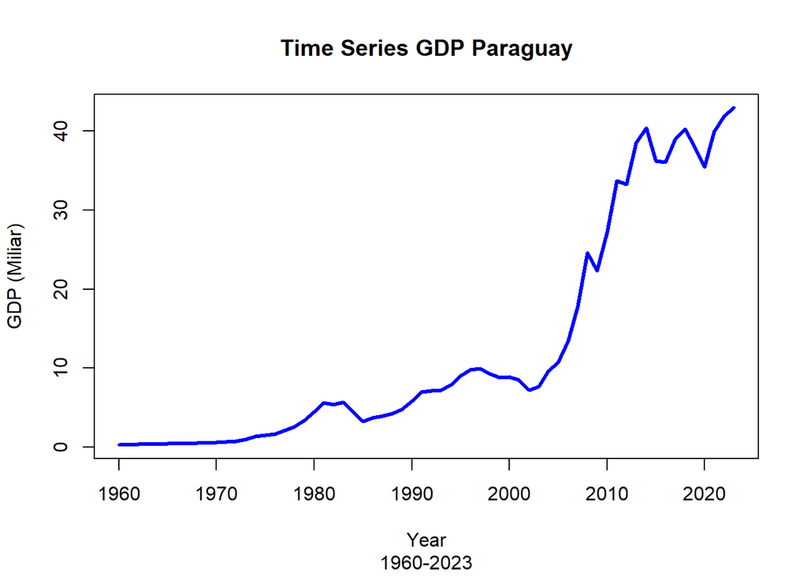

```r
gdp.ts <- ts(dt$GDP, start=c(1960,1), end=c(2023,1), frequency=1)
plot(gdp.ts,
     lwd=3,
     col="blue",
     main="Time Series GDP Paraguay",
     sub="1960-2023",
     xlab="Year",
     ylab="GDP (Miliar)")
```

Terdapat kenaikan yang tinggi pada tahun 2000 awal. Untuk keperluan analisis dan tugas ini, kita akan mengambil sampai tahun 2000 saja.

### Subsetting 1960-2000

```r
gdp.new <- dt %>% filter(Year <= 2000)
```

## Pemodelan Regresi Linear

```r
model.reg <- lm(GDP~Year,data=gdp.new)
summary(model.reg)
```

```
##
## Call:
## lm(formula = GDP ~ Year, data = gdp.new)
##
## Residuals:
##      Min       1Q   Median       3Q      Max
## -1.81064 -0.94585  0.00392  0.84203  1.88154
##
## Coefficients:
##               Estimate Std. Error t value Pr(>|t|)
## (Intercept) -502.66344   27.75730  -18.11   <2e-16 ***
## Year           0.25580    0.01402   18.25   <2e-16 ***
## ---
## Signif. codes:  0 '***' 0.001 '**' 0.01 '*' 0.05 '.' 0.1 ' ' 1
##
## Residual standard error: 1.062 on 39 degrees of freedom
## Multiple R-squared:  0.8951, Adjusted R-squared:  0.8925
## F-statistic:   333 on 1 and 39 DF,  p-value: < 2.2e-16
```

Didapatkan hasil pemodelan dari regresi linear adalah

$$\begin{equation}
\hat{y} = -502.663 + 0.256 Year
\end{equation}$$

### Uji asumsi kenormalan sisaan

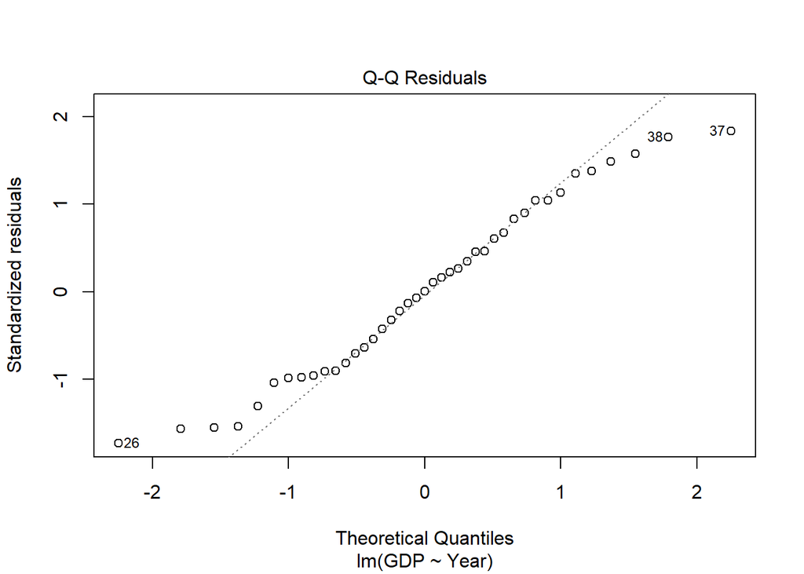

```r
plot(model.reg, which=2)
```

```r
resid.reg <- residuals(model.reg)
shapiro.test(resid.reg)
```

```
##
##  Shapiro-Wilk normality test
##
## data:  resid.reg
## W = 0.96501, p-value = 0.2346
```

Asumsi normalitas sisaan terpenuhi

### Uji asumsi homoskedastisitas

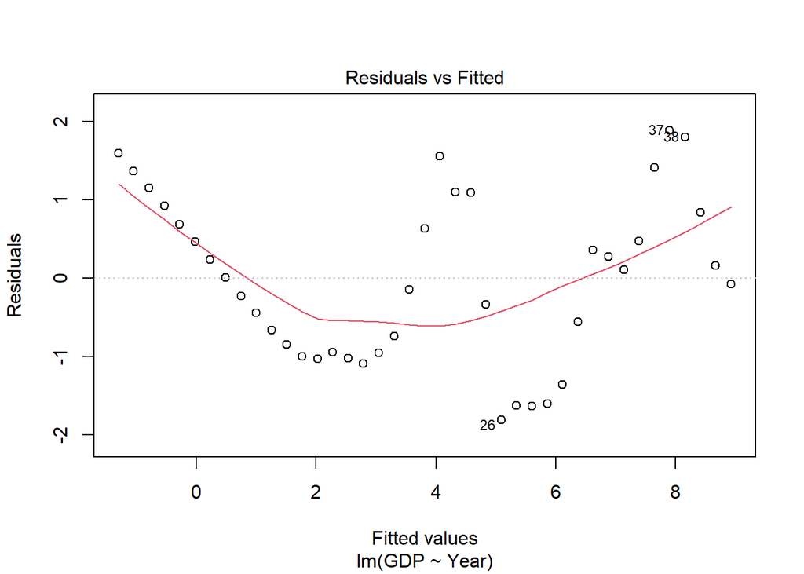

```r
plot(model.reg, which=1)
```

Seperti ada pola dalam Residual Vs Fitted.

```r
bptest(model.reg)
```

```
##
##  studentized Breusch-Pagan test
##
## data:  model.reg
## BP = 0.94964, df = 1, p-value = 0.3298
```

Walaupun secara eksplorasi terlihat ragam tidak homogen karena berpola, namun uji formal menunjukan homosskedasitas ragam sisaan.

### Uji asumsi autokorelasi

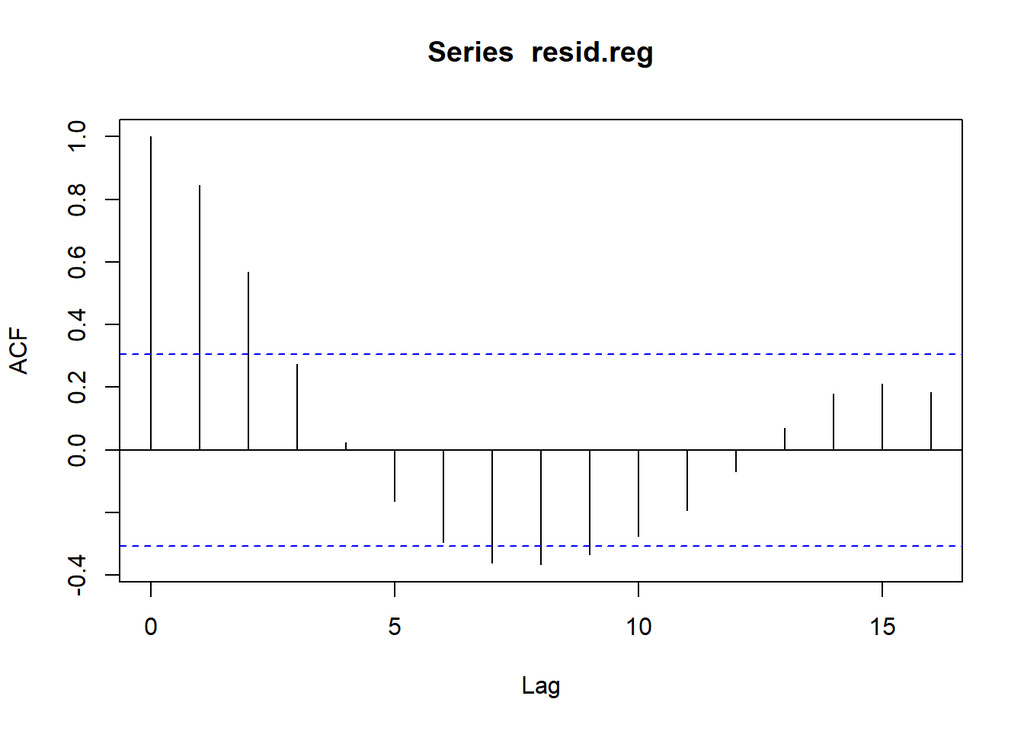

```r
acf(resid.reg)
```

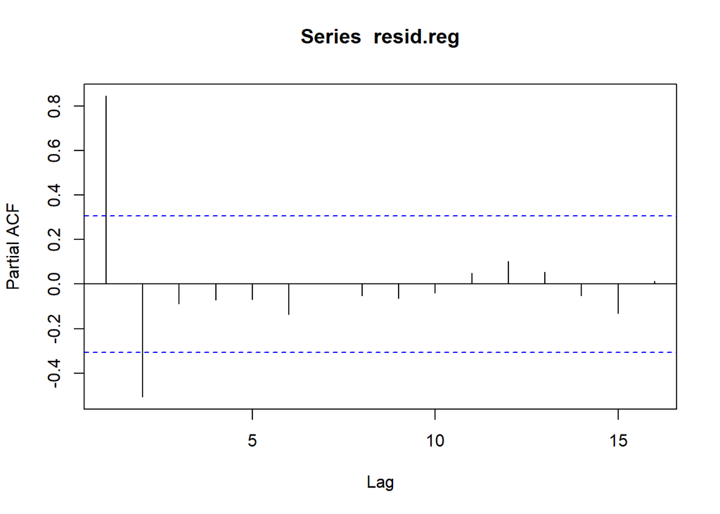

```r
pacf(resid.reg)
```

Plot ACF dan PACF menunjukan bahwa terdapat pengaruh lag 1 pada sisaan. Hal ini mengindikasikan adanya autokorelasi.

```r
dwtest(model.reg)
```

```
##
##  Durbin-Watson test
##
## data:  model.reg
## DW = 0.25383, p-value = 6.492e-16
## alternative hypothesis: true autocorrelation is greater than 0
```

Uji Durbin-Watson mendukung temuan kita sebelumnya. Terdapat autokorelasi pada model regresi linear. Autokorelasi yang terjadi cenderung autokorelasi positif. Karena itu kita lakukan penanganan autokorelasi.

## Penanganan Autokorelasi

### Cochrane-Orcutt

```r
CO <- cochrane.orcutt(model.reg)
summary(CO)
```

```
## Call:
## lm(formula = GDP ~ Year, data = gdp.new)
##
##                Estimate  Std. Error t value  Pr(>|t|)
## (Intercept) -577.854237   88.907941  -6.499 1.179e-07 ***
## Year           0.293525    0.044768   6.557 9.851e-08 ***
## ---
## Signif. codes:  0 '***' 0.001 '**' 0.01 '*' 0.05 '.' 0.1 ' ' 1
##
## Residual standard error: 0.5091 on 38 degrees of freedom
## Multiple R-squared:  0.5308 ,  Adjusted R-squared:  0.5184
## F-statistic: 43 on 1 and 38 DF,  p-value: < 9.851e-08
##
## Durbin-Watson statistic
## (original):    0.25383 , p-value: 6.492e-16
## (transformed): 0.95397 , p-value: 7.588e-05
```

Didapat persamaan regersi Cochrane-Orcutt adalah
$$\begin{equation}
\hat{y_{CO}} = -577.854 + 0.294 Year
\end{equation}$$
#### Uji autokorelasi

```r
dwtest(CO)
```

```
##
##  Durbin-Watson test
##
## data:  CO
## DW = 0.95397, p-value = 7.588e-05
## alternative hypothesis: true autocorrelation is greater than 0
```

Uji Durbin-Watson menunjukan bahwa autokorelasi belum juga teratasi

### Hildreth-Lu

Mencari nilai rho yang meminimumkan SSE

```r
hildreth.lu.func<- function(r, model){
  x <- model.matrix(model)[,-1]
  y <- model.response(model.frame(model))
  n <- length(y)
  t <- 2:n
  y <- y[t]-r*y[t-1]
  x <- x[t]-r*x[t-1]

  return(lm(y~x))
}

#Pencariab rho yang meminimumkan SSE
r <- c(seq(0.1,0.9, by= 0.1))
tab <- data.frame("rho" = r, "SSE" = sapply(r, function(i){deviance(hildreth.lu.func(i, model.reg))}))
round(tab, 4)
```

| rho | SSE |
| --- | --- |
| 0.1 | 34.2128 |
| 0.2 | 28.1053 |
| 0.3 | 22.8776 |
| 0.4 | 18.5296 |
| 0.5 | 15.0614 |
| 0.6 | 12.4729 |
| 0.7 | 10.7641 |
| 0.8 | 9.9351 |
| 0.9 | 9.9858 |

nilai SSE terkecil didapat pada antara 0.8-0.9

```r
#Rho optimal di sekitar 0.8-0.9
rOpt <- seq(0.75,0.95, by= 0.001)
tabOpt <- data.frame("rho" = rOpt, "SSE" = sapply(rOpt, function(i){deviance(hildreth.lu.func(i, model.reg))}))
head(tabOpt[order(tabOpt$SSE),])
```

|  | rho | SSE |
| --- | --- | --- |
| 95 | 0.844 | 9.848988 |
| 96 | 0.845 | 9.849011 |
| 94 | 0.843 | 9.849053 |
| 97 | 0.846 | 9.849123 |
| 93 | 0.842 | 9.849205 |
| 98 | 0.847 | 9.849322 |

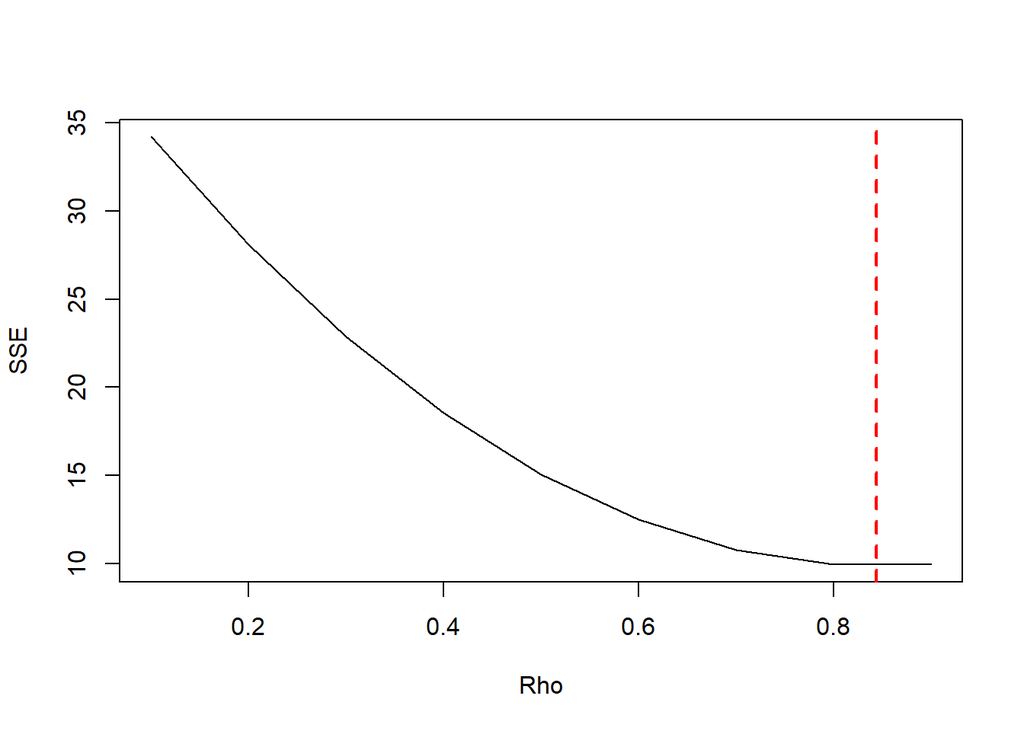

```r
#Grafik SSE optimum
par(mfrow = c(1,1))
plot(tab$SSE ~ tab$rho , type = "l", xlab = "Rho", ylab = "SSE")
abline(v = tabOpt[tabOpt$SSE==min(tabOpt$SSE),"rho"], lty = 2, col="red",lwd=2)
```

```r
## Optimum
tabOpt[tabOpt$SSE==min(tabOpt$SSE),"rho"]
```

```
## [1] 0.844
```

Nilai rho optimum yang di dapat adalah 0.844

```r
HidL <- hildreth.lu.func(0.844,model = model.reg)
summary(HidL)
```

```
##
## Call:
## lm(formula = y ~ x)
##
## Residuals:
##      Min       1Q   Median       3Q      Max
## -1.51315 -0.18425 -0.04378  0.16456  1.05793
##
## Coefficients:
##             Estimate Std. Error t value Pr(>|t|)
## (Intercept) -90.1276    13.8486  -6.508 1.15e-07 ***
## x             0.2935     0.0447   6.565 9.59e-08 ***
## ---
## Signif. codes:  0 '***' 0.001 '**' 0.01 '*' 0.05 '.' 0.1 ' ' 1
##
## Residual standard error: 0.5091 on 38 degrees of freedom
## Multiple R-squared:  0.5315, Adjusted R-squared:  0.5191
## F-statistic:  43.1 on 1 and 38 DF,  p-value: 9.587e-08
```

```r
#transform balik
cat("y = ", coef(HidL)[1]/(1-0.844), "+", coef(HidL)[2],"x", sep = "")
```

```
## y = -577.7413+0.2934686x
```

Persamaan yang terbentuk dari pemodelan hidret-lu adalah

$$\begin{equation}
\hat{y_{HL}} = -577.741 + 0.293 Year
\end{equation}$$

#### Uji autokorelasi

```r
dwtest(HidL)
```

```
##
##  Durbin-Watson test
##
## data:  HidL
## DW = 0.95379, p-value = 7.566e-05
## alternative hypothesis: true autocorrelation is greater than 0
```

Autokorelasi juga masih ada.

## Kesimpulan

Dari hasil analisis, kita menemukan bahwa autokorelasi masih ada pada model regresi linear. Penanganan autokorelasi dengan metode Cochrane-Orcutt dan Hildreth-Lu juga belum mampu menghilangkan autokorelasi. Diperlukan metode lain untuk mengatasi autokorelasi pada model regresi linear ini.